# 230224_iPSC-differentiation

George Young

george.young@lms.mrc.ac.uk

230428

**iPSC > PGCLC > EGCLC differentiation**

# Setup

## Packages

```r
packages = c(
  # functional #################################################################
  "tidyverse", "magrittr", "glue", "here", "data.table",
  # display ####################################################################
  "DT", "pheatmap", "RColorBrewer",
  # stats ######################################################################
  "tximport", "GenomicFeatures", "DESeq2", "PCAtools", "IHW", "ashr",
  "variancePartition", "DEGreport",
  # annotation #################################################################
  "AnnotationDbi", "org.Hs.eg.db",
  # enrichment analysis ########################################################
  "clusterProfiler")

invisible(lapply(packages, library, character.only=TRUE))
```

## Environment

```r
"%ni%" = Negate("%in%")

outputs = list(
  "outputs"="outputs",
  "figures"="outputs/figures",
  "snapshots"="outputs/r_snapshots",
  "contrasts"="outputs/contrasts")
purrr::walk(
  outputs, function(d) {
    d = here(d)
    if (!dir.exists(d)) { dir.create(d, recursive=T) }
  }
)

save_snapshot = function(snap, threads=4) {
  # make a workspace image, using pigz to speed up saving

  .GlobalEnv$current_snapshot = snap
  con = pipe(
    glue(
      "pigz -p {threads} > \\
      {here(outputs$snapshots, glue(\"save_point_{snap}.rda.gz\"))}"),
    "wb")
  save(file=con, list=setdiff(ls(name=.GlobalEnv), lsf.str(name=.GlobalEnv)))
  close(con)
}

load_snapshot = function(snap=-1, threads=4) {
  # load a workspace image, using pigz to speed up saving

  available_snaps = as.numeric(
    stringr::str_extract(
      list.files(here(outputs$snapshots)), "[0-9]+"))
  if (length(available_snaps)) {
    if (snap == -1) { snap = max(available_snaps) }
    if (snap %in% available_snaps) {
      cat("Loading snapshot", snap, "\n")
      load(
        here(outputs$snapshots, glue("save_point_{snap}.rda.gz")),
        envir=.GlobalEnv)
    } else {
      stop("Error! Specified snapshot not found")
    }
  } else {
    cat("No snapshots available\n")
    .GlobalEnv$current_snapshot = snap
  }
}

ggsaver = function(
  basename, plot=ggplot2::last_plot(), device=c("png", "svg"), ...) {
  # wrapper around ggplot2::ggsave automating saving of multiple image formats

  args = c(as.list(environment()), list(...))
  device = c(device)
  args$basename = NULL

  written = c()

  for (d in device) {
    args$filename = glue("{basename}.{d}")
    args$device = d
    do.call(ggplot2::ggsave, args)
    written = c(written, args$filename)
  }

  return(written)

}

contrast_and_save = function(
    contrast_name, plot_result=T, write_table=T, ...) {
  # run and return the output of DESeq2::results for a given contrast and
  # parameter set, additionally filtering and saving the results table

  args = c(as.list(environment()), list(...))
  args$contrast_name = NULL
  args$plot_result = NULL
  args$write_table = NULL

  res = rlang::exec(DESeq2::results, !!!args, filterFun=IHW::ihw)
  res = DESeq2::lfcShrink(dds=args$object, res=res, type="ashr")

  if (plot_result) {
    ma_data = DESeq2::plotMA(res, alpha=args$alpha, returnData=T)
    y_limit = ceiling(max(abs(quantile(ma_data$lfc, c(0.001, 0.999)))))
    g =
      ggplot2::ggplot(ma_data, aes(mean, lfc, color=isDE)) +
      ggplot2::geom_point(alpha=0.33, size=1, stroke=0) +
      ggplot2::geom_hline(yintercept=c(-args$lfcThreshold, args$lfcThreshold)) +
      ggplot2::scale_color_manual(values=c(`TRUE`="blue", `FALSE`="grey75")) +
      ggplot2::coord_cartesian(ylim=c(-y_limit, y_limit)) +
      ggplot2::scale_x_continuous(trans="log10") +
      ggplot2::labs(
        x="Mean of normalized counts",
        y="Shrunken log2 Fold-Change",
        title=contrast_name) +
      ggplot2::theme_bw() +
      ggplot2::theme(legend.position="none")
    ggsaver(glue("{contrast_name}_MAplot"), g, path=outputs$contrasts, height=5, width=5)
  }

  res = res %>%
    data.frame() %>%
    dplyr::filter(padj<args$alpha, abs(log2FoldChange)>=args$lfcThreshold) %>%
    dplyr::arrange(desc(log2FoldChange), padj) %>%
    tibble::rownames_to_column(var="gene_id")

  gene_name = biomaRt::getBM(
    filters="ensembl_gene_id",
    attributes=c("ensembl_gene_id", "external_gene_name", "description"),
    values=res$gene_id,
    mart=mart)
  gene_name$description = sub("(.*) \\[.*\\]$", "\\1", gene_name$description)
  names(gene_name) = c("gene_id", "gene_symbol", "gene_description")

  res = dplyr::left_join(res, gene_name, by="gene_id")

  if (write_table) readr::write_tsv(
    res, here(outputs$contrasts, glue("{contrast_name}.tsv")))

  return(res)
}

options(bitmapType='cairo')
```

```r
load_snapshot()
```

```
## Loading snapshot 3
```

```r
snap = if (exists("snap")) max(1, snap) else 1

# Stats settings
stats = list(
  "alpha"=0.01,
  "l2FC"=log2(1))
```

```r
if (snap > current_snapshot) {
  mart = biomaRt::useDataset("hsapiens_gene_ensembl", biomaRt::useMart("ensembl"))
}
```

# Project design

One pool of human induced pluripotent stem cells (`hIPSC`) were differentiated into germ cell-like cells (`hPGCLC`), which can be isolated by FACS sorting on GFP<sup>+</sup> tdTomato<sup>+</sup>. With further culture, these `hPGCLC` are converted into `hEGCLC`.

```r
meta_data =
  readr::read_tsv("SampleAnnot.txt") %>%
  mutate(
    Group=forcats::as_factor(Group),
    Batch=forcats::as_factor(Batch))
```

| Sample | Name | Group | Batch | Conc | RIN | Perc_mapped |
| --- | --- | --- | --- | --- | --- | --- |
| IPS-1 | hIPSC3 | hIPSC | 3 | 113 | 9 | 90.8 |
| IPS-2 | hIPSC2 | hIPSC | 2 | 46.3 | 10 | 92.1 |
| IPS-3 | hIPSC1 | hIPSC | 1 | 125 | 10 | 90.1 |
| PGCLC-2 | hPGCLC2 | hPGCLC | 2 | 0.2 | 9.8 | 84.3 |
| PGCLC-3 | hPGCLC1 | hPGCLC | 1 | 1.2 | 9.7 | 91.4 |
| EGCLC-P0-1 | hEGCLC3_P0 | hEGCLC_P0 | 3 | 66.2 | 7.7 | 85.8 |
| EGCLC-P0-2 | hEGCLC2_P0 | hEGCLC_P0 | 2 | 30.1 | 7.8 | 91.7 |
| EGCLC-P0-3 | hEGCLC1_P0 | hEGCLC_P0 | 1 | 155 | 9.7 | 91 |
| EGCLC-P3-1-1 | hEGCLC3_P3_1 | hEGCLC_P3 | 3 | 19.4 | 10 | 92.1 |
| EGCLC-P3-1-2 | hEGCLC3_P3_2 | hEGCLC_P3 | 3 | 17.3 | 10 | 92.7 |

[output cut: 16 more lines]

# Analysis methodology

Reads were processed using `cutadapt v4.1` (Martin 2011) to remove Illumina adapters, trim, and filter on quality with the settings:

> -a AGATCGGAAGAGCACACGTCTGAACTCCAGTCA -A AGATCGGAAGAGCGTCGTGTAGGGAAAGAGTGT -n 1 -m 31 --nextseq-trim 20 --max-n 0

> -l A --softclip --softclipOverhangs --allowDovetail --seqBias --gcBias

Transcript level counts were aggregated to the gene level allowing normalisation and differential expression analyses within `DESeq2` (Love, Huber, and Anders 2014).

Within `DESeq2`, independent hypothesis weighting was conducted to optimise the power of *p value* filtering using `IHW` (Ignatiadis et al. 2016) and Log2 fold-change shrinkage was performed using `ashr` (Stephens 2017). Multiple correction testing adjustments were optimised by passing FDR and log2FC thresholds at the point of results generation.

# Data import

Make/import transcript:gene mappings for Ensembl GRCh38 v107 annotations.

```r
if (snap > current_snapshot) {

  #
  # Previously run
  #
  # txdb = AnnotationDbi::makeTxDbFromEnsembl("Homo sapiens", 102)
  # AnnotationDbi::saveDb(txdb, "/rds/general/project/lms-bioinformatics-raw/live/resources/genomes/Homo_sapiens/GRCh38/107/annotation/GRCh38.txdb")
  #

  txdb = AnnotationDbi::loadDb("/rds/general/project/lms-bioinformatics-raw/live/resources/genomes/Homo_sapiens/GRCh38/107/annotation/GRCh38.txdb")

}
```

Import transcript counts from Salmon, convert to gene-level count estimates, and clean up the table.

```r
if (snap > current_snapshot) {

  salmon_files = here("salmon", meta_data$Sample, "quant.sf")
  names(salmon_files) = meta_data$Name

  salmon_data = tximport::tximport(
    salmon_files,
    type="salmon",
    tx2gene=AnnotationDbi::select(txdb, keys(txdb, keytype="TXNAME"), "GENEID", "TXNAME"),
    ignoreTxVersion=T)

  # post import, we rename to a preferred naming system
  meta_data =
    dplyr::mutate(meta_data, Sample=Name) %>%
    dplyr::select(-Name)

  # prepare a dummy dds - we will add the design later
  dds = DESeq2::DESeqDataSetFromTximport(salmon_data, meta_data, ~0)
  # discard genes with no counts
  dds = dds[rowSums(assay(dds))>0, ]
  dds = DESeq2::estimateSizeFactors(dds)

  rm(salmon_files, salmon_data, txdb)

}
```

# Quality control

- Prior QC indicates that `hPGCLC2` has a notably different GC content to the other samples and a higher proportion of duplication in the sequencing. This sample has an extremely low concentration, which is the likely explanatory factor.
- `hPGCLC1` also has a very low sample concentration, but does not present poorly in prior QC.

The behaviour of these samples will be assessed specifically as we move forward. One `hPGCLC` sample has already been dropped from the sequencing - presumably for the same reason?

## Gene observation metrics

```r
if (snap > current_snapshot) {

  g =
    ggplot2::ggplot(
      meta_data, ggplot2::aes(x=log2(Conc), y=Perc_mapped, color=RIN)) +
    ggplot2::geom_text(mapping=aes(label=Sample)) +
    ggplot2::scale_color_continuous(na.value="red") +
    ggplot2::xlab("log2 sample concentration (ng/ul)") +
    ggplot2::ylab("Percentage reads mapped") +
    ggplot2::theme_bw()

  ggsaver(
    "Perc_mapped-vs-Conc", g, path=outputs$figures,
    height=15, width=17, units="cm")

  g =
    ggplot2::ggplot(
      meta_data, ggplot2::aes(x=RIN, y=Perc_mapped, color=log2(Conc))) +
    ggplot2::geom_text(mapping=aes(label=Sample)) +
    ggplot2::scale_color_continuous(na.value="red") +
    ggplot2::xlab("RIN") +
    ggplot2::ylab("Percentage reads mapped") +
    ggplot2::theme_bw()

  ggsaver(
    "Perc_mapped-vs-RIN", g, path=outputs$figures,
    height=15, width=17, units="cm")

  g =
    ggplot2::ggplot(
      meta_data %>% dplyr::mutate(Num_Genes=colSums(assay(dds)>10)),
      ggplot2::aes(x=Sample, y=Num_Genes)) +
    ggplot2::geom_col() +
    ggplot2::ylab("Number of genes recovered") +
    ggplot2::theme_bw() +
    ggplot2::theme(axis.text.x=element_text(angle=90, vjust=0.5, hjust=1))

  ggsaver(
    "Num_Genes", g, path=outputs$figures,
    height=10, width=20, units="cm")

  g =
    ggplot2::ggplot(
      counts(dds, normalized=T) %>%
        data.table() %>%
        tidyr::gather(key="Sample", value="Norm_Counts", factor_key=T) %>%
        dplyr::mutate(Norm_Counts=log2(Norm_Counts)) %>%
        dplyr::left_join(., meta_data %>% dplyr::select(Sample, Perc_mapped)),
      ggplot2::aes(x=Norm_Counts, group=Sample, color=Sample)) +
    ggplot2::geom_density() +
    ggplot2::xlab("log2 normalised gene expression") +
    ggplot2::theme_bw()

  ggsaver(
    "Gene_expression", g, path=outputs$figures,
    height=15, width=20, units="cm")

  rm(g)

}
```

### Mapping vs Concentration

[figure not shown]

### Mapping vs RIN

[figure not shown]

### Genes represented

[figure not shown]

### Gene expression

[figure not shown]

- `hPGCLC2` likely had poor library prep due to its low concentration. Read mapping is lower for this sample as a result and it displays differences in its gene expression profile.

## Data exploration

### PCA

```r
if (snap > current_snapshot) {

  pca = PCAtools::pca(
    assay(DESeq2::vst(dds)),
    tibble::column_to_rownames(meta_data, "Sample"),
    removeVar=0.1)

  g =
    ggplot2::ggplot(
      data.frame(PC1=pca$rotated$PC1, PC2=pca$rotated$PC2, Sample=rownames(pca$metadata), pca$metadata),
      ggplot2::aes(PC1, PC2, color=Group, shape=Batch)) +
    ggplot2::geom_point(size=2) +
    ggrepel::geom_text_repel(mapping=aes(label=Sample), show.legend=FALSE) +
    ggplot2::labs(
      x=glue('PC1: {round(pca$variance["PC1"])}% variance'),
      y=glue('PC2: {round(pca$variance["PC2"])}% variance')) +
    ggplot2::coord_fixed() +
    ggplot2::theme_bw()

  ggsaver(
    "PCA", g, path=outputs$figures,
    height=20, width=25, units="cm")

  rm(pca, g)

}
```

[figure not shown]

### Inter-sample distance

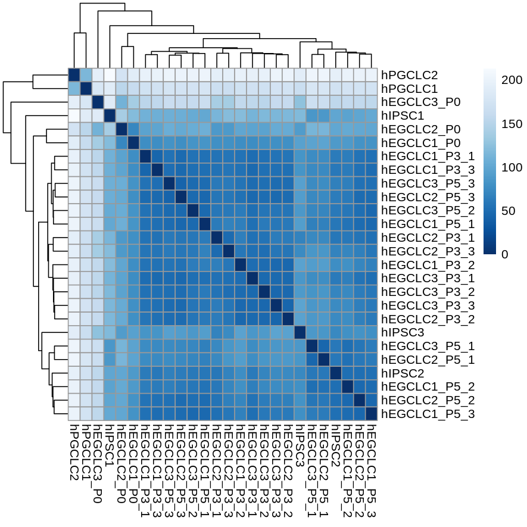

```r
# eval=FALSE

if (snap > current_snapshot) {

  dists = dist(t(assay(DESeq2::vst(dds))))
  dist_mat = as.matrix(dists)

  colnames(dist_mat) = dds$Sample

  png(
    here(outputs$figures, "Heatmap.png"),
    width=15, height=15, units="cm", res=150)
  pheatmap(
    dist_mat,
    clustering_distance_rows=dists,
    clustering_distance_cols=dists,
    col=colorRampPalette( rev(brewer.pal(9, "Blues")) )(255))
  dev.off()

  rm(dists, dist_mat)

}
```

- Despite the low sample concentration of `hPGCLC1`, it falls with `hPGCLC2` and, together, the difference between this group and the remainder of the samples is the dominant factor behind PC1.
- The PC2 signature is minimal.

We do not have sufficient reason to exclude any samples from this analysis.

# Data curation

```r
if (snap > current_snapshot) {

  # meta_data =
  #   meta_data %>%
  #   dplyr::filter(Sample %ni% c())
  #
  # dds = dds[, colnames(dds) %in% meta_data$Sample]
  # dds = DESeq2::estimateSizeFactors(dds)

}
```

# Differential Gene Expression

We will assess the following model:

> ~ 0 + Group + Batch

```r
if (snap > current_snapshot) {
  DESeq2::design(dds) = ~ 0 + Group + Batch
  dds = DESeq2::DESeq(dds)
}
```

```r
resultsNames(dds)
```

```
## [1] "GrouphIPSC"     "GrouphPGCLC"    "GrouphEGCLC_P0" "GrouphEGCLC_P3"
## [5] "GrouphEGCLC_P5" "Batch2"         "Batch3"
```

```r
if (snap > current_snapshot) {

  contrast_args = list(
    alpha=stats$alpha, lfcThreshold=stats$l2FC,  altHypothesis="greaterAbs")

  # define the contrasts
  contrasts = list(
    "hEGCLC_P3_v_hIPSC"=list(
      contrast_args=append(
        contrast_args, list(contrast=list("GrouphEGCLC_P3", "GrouphIPSC"))),
      contrast_samples=
        meta_data %>%
          dplyr::filter(Group %in% c("hEGCLC_P3", "hIPSC")) %>%
          dplyr::pull(Sample)),
    "hEGCLC_P5_v_hIPSC"=list(
      contrast_args=append(
        contrast_args, list(contrast=list("GrouphEGCLC_P5", "GrouphIPSC"))),
      contrast_samples=
        meta_data %>%
          dplyr::filter(Group %in% c("hEGCLC_P5", "hIPSC")) %>%
          dplyr::pull(Sample)),
    "hEGCLC_P3_v_hEGCLC_P5"=list(
      contrast_args=append(
        contrast_args, list(contrast=list("GrouphEGCLC_P3", "GrouphEGCLC_P5"))),
      contrast_samples=
        meta_data %>%
          dplyr::filter(Group %in% c("hEGCLC_P3", "hEGCLC_P5")) %>%
          dplyr::pull(Sample)),
    "hIPSC_v_hEGCLC_P0"=list(
      contrast_args=append(
        contrast_args, list(contrast=list("GrouphIPSC", "GrouphEGCLC_P0"))),
      contrast_samples=
        meta_data %>%
          dplyr::filter(Group %in% c("hIPSC", "hEGCLC_P0")) %>%
          dplyr::pull(Sample)),
    "hPGCLC_v_hEGCLC_P0"=list(
      contrast_args=append(
        contrast_args, list(contrast=list("GrouphPGCLC", "GrouphEGCLC_P0"))),
      contrast_samples=
        meta_data %>%
          dplyr::filter(Group %in% c("hPGCLC", "hEGCLC_P0")) %>%
          dplyr::pull(Sample)),
    "hEGCLC_P0_v_hEGCLC_P3"=list(
      contrast_args=append(
        contrast_args, list(contrast=list("GrouphEGCLC_P0", "GrouphEGCLC_P3"))),
      contrast_samples=
        meta_data %>%
          dplyr::filter(Group %in% c("hEGCLC_P0", "hEGCLC_P3")) %>%
          dplyr::pull(Sample)),
    "hEGCLC_P0_v_hEGCLC_P5"=list(
      contrast_args=append(
        contrast_args, list(contrast=list("GrouphEGCLC_P0", "GrouphEGCLC_P5"))),
      contrast_samples=
        meta_data %>%
          dplyr::filter(Group %in% c("hEGCLC_P0", "hEGCLC_P5")) %>%
          dplyr::pull(Sample)))

  # run the contrasts
  purrr::map(
    names(contrasts),
    function(contrast) {
      contrasts[[contrast]]$results <<- rlang::exec(
        contrast_and_save,
        contrast_name=contrast, object=dds, !!!contrasts[[contrast]]$contrast_args)
    })

  # plot the heatmaps
  purrr::map(
    names(contrasts),
    function(contrast) {
      vsd =
        assay(DESeq2::vst(dds))[
          rownames(dds) %in% contrasts[[contrast]]$results$gene_id,
          colnames(dds) %in% contrasts[[contrast]]$contrast_samples]
      if (is.null(nrow(vsd))) return(NULL)
      vsd = vsd[apply(vsd, 1, function(x) length(unique(x)) != 1), ]
      if (is.null(nrow(vsd))) return(NULL)
      annot =
        meta_data %>%
          tibble::column_to_rownames("Sample") %>%
          dplyr::select(Group, Batch)
      png(
        here(outputs$contrasts, glue("{contrast}_heatmap.png")),
        width=15, height=20, units="cm", res=150)
      pheatmap::pheatmap(
        vsd,
        annotation=annot,
        scale="row",
        cluster_rows=TRUE,
        cluster_cols=TRUE,
        show_rownames=FALSE,
        show_colnames=TRUE,
        color=colorRampPalette(rev(brewer.pal(n=7, name="RdBu")))(100),
        fontsize=6)
      dev.off()
    })

  rm(contrast_args)

}
```

## Contrasts

```r
for (contrast in names(contrasts)){
  cat(glue("### {contrast}"))
  cat("\n\n")
  cat(glue('![]({here(outputs$contrasts, glue("{contrast}_MAplot.png"))})'))
  cat("\n\n")
  cat(glue('![]({here(outputs$contrasts, glue("{contrast}_heatmap.png"))})'))
  cat("\n\n")
}
```

### hEGCLC_P3_v_hIPSC

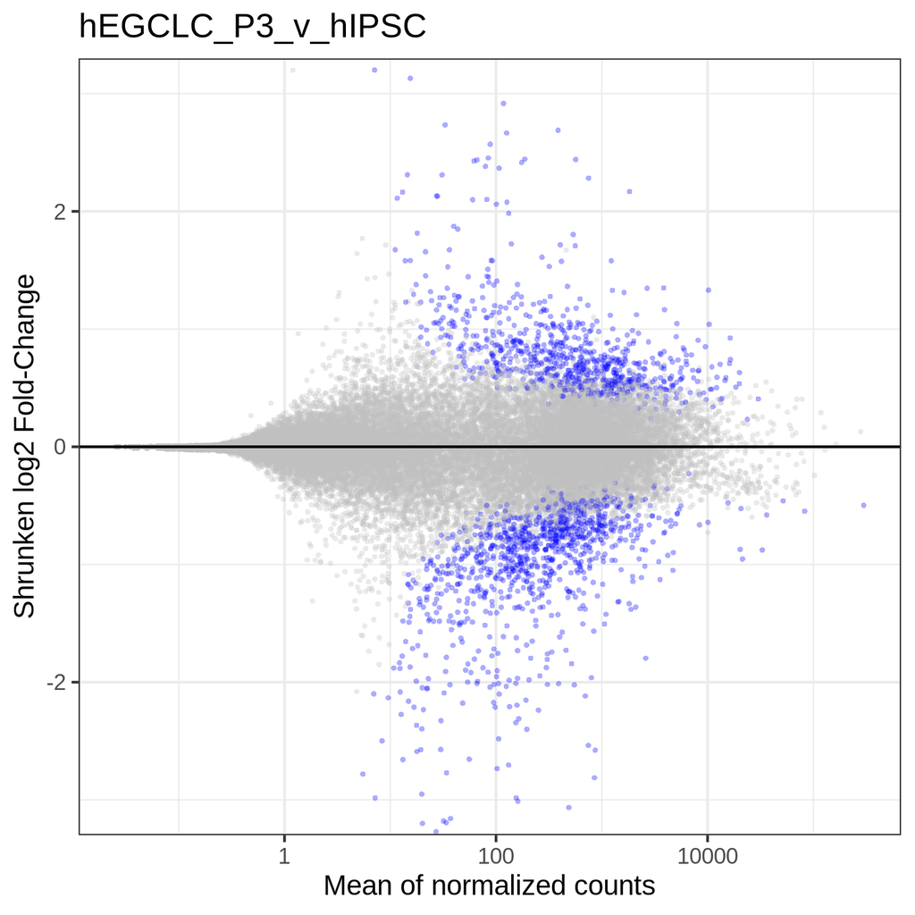

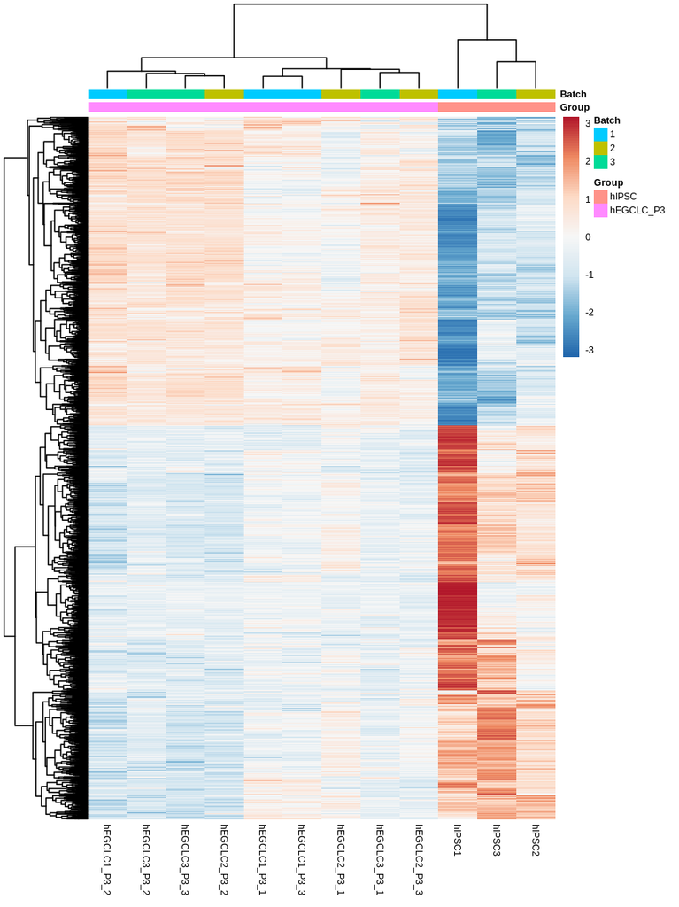

### hEGCLC_P5_v_hIPSC

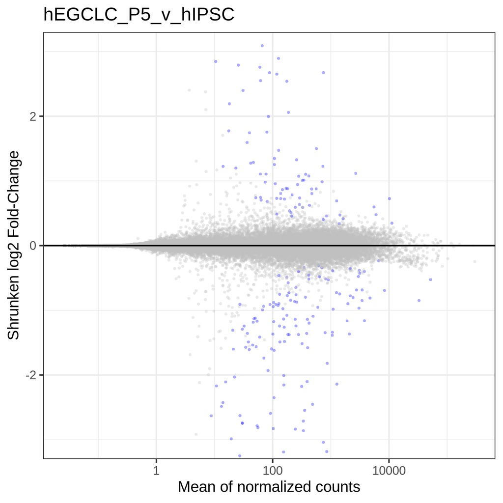

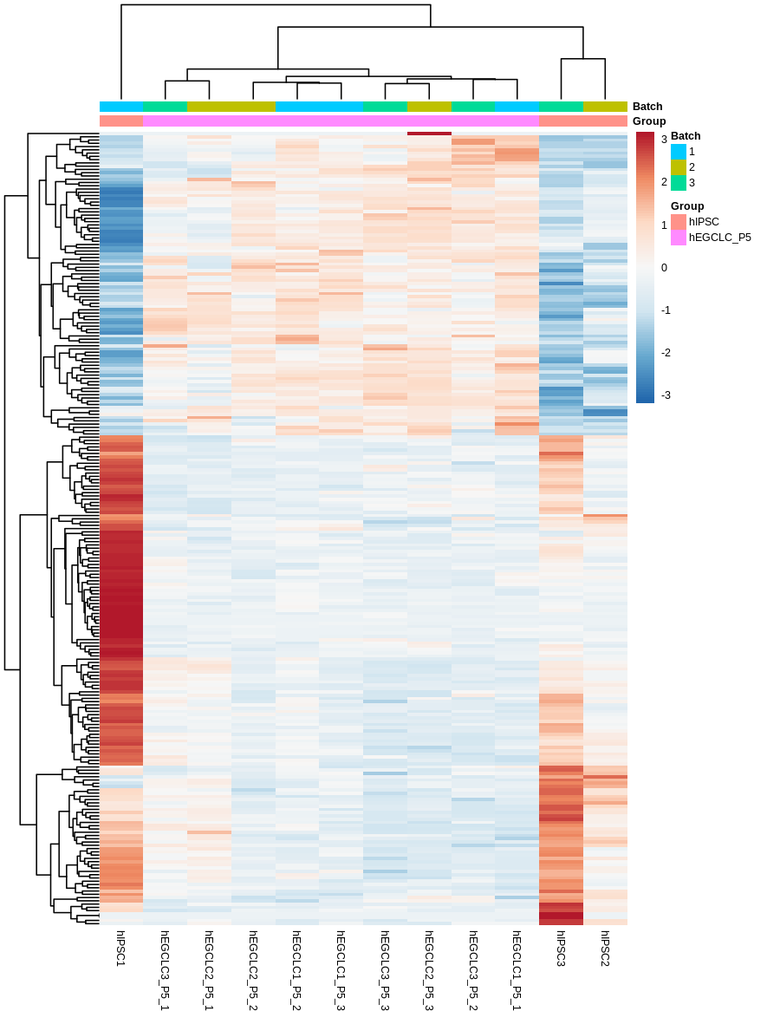

### hEGCLC_P3_v_hEGCLC_P5

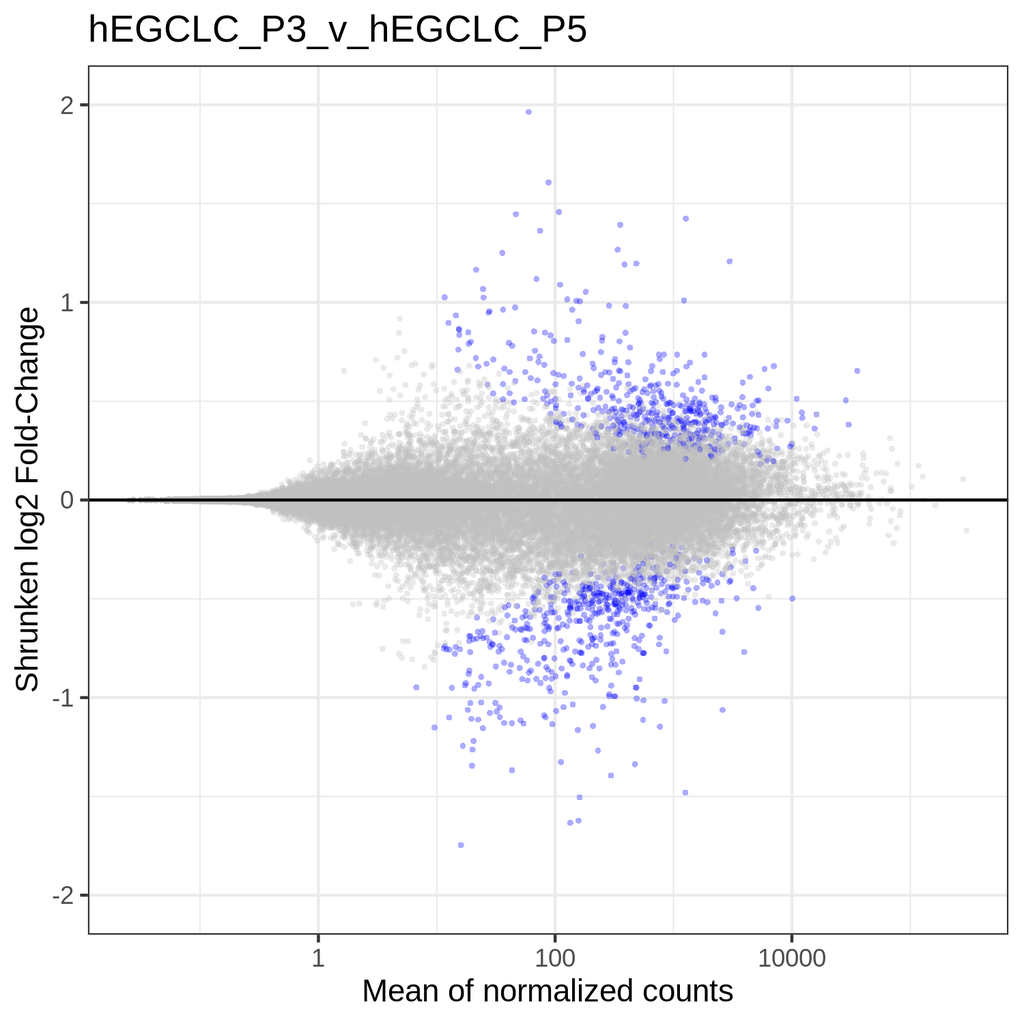

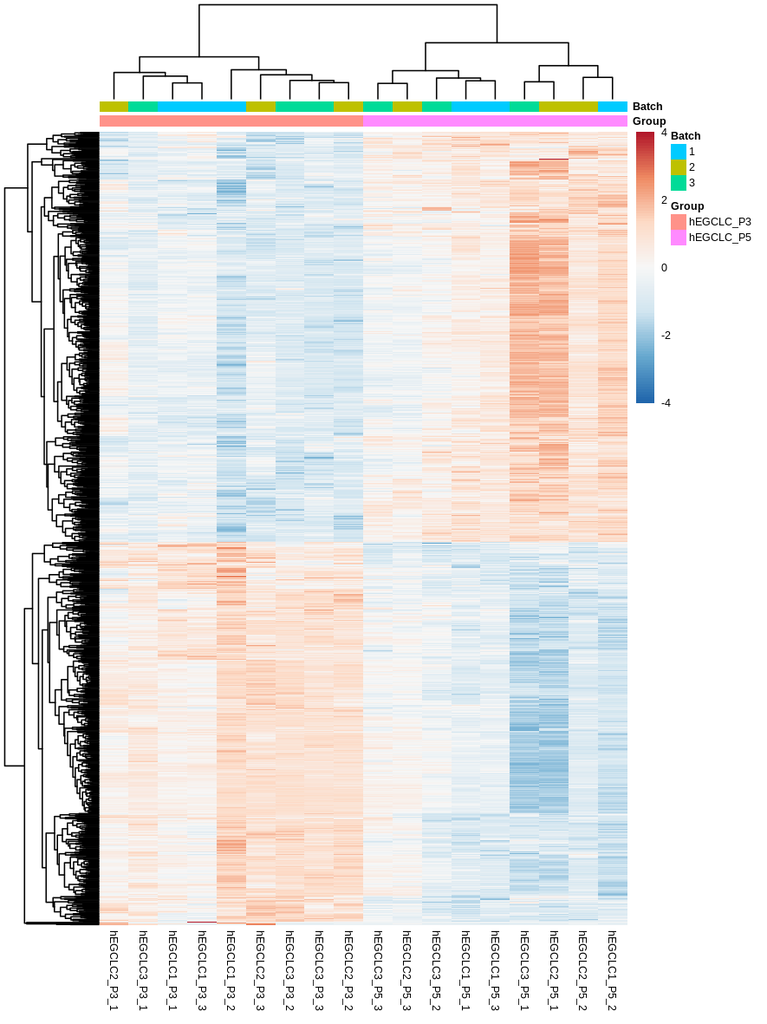

### hIPSC_v_hEGCLC_P0

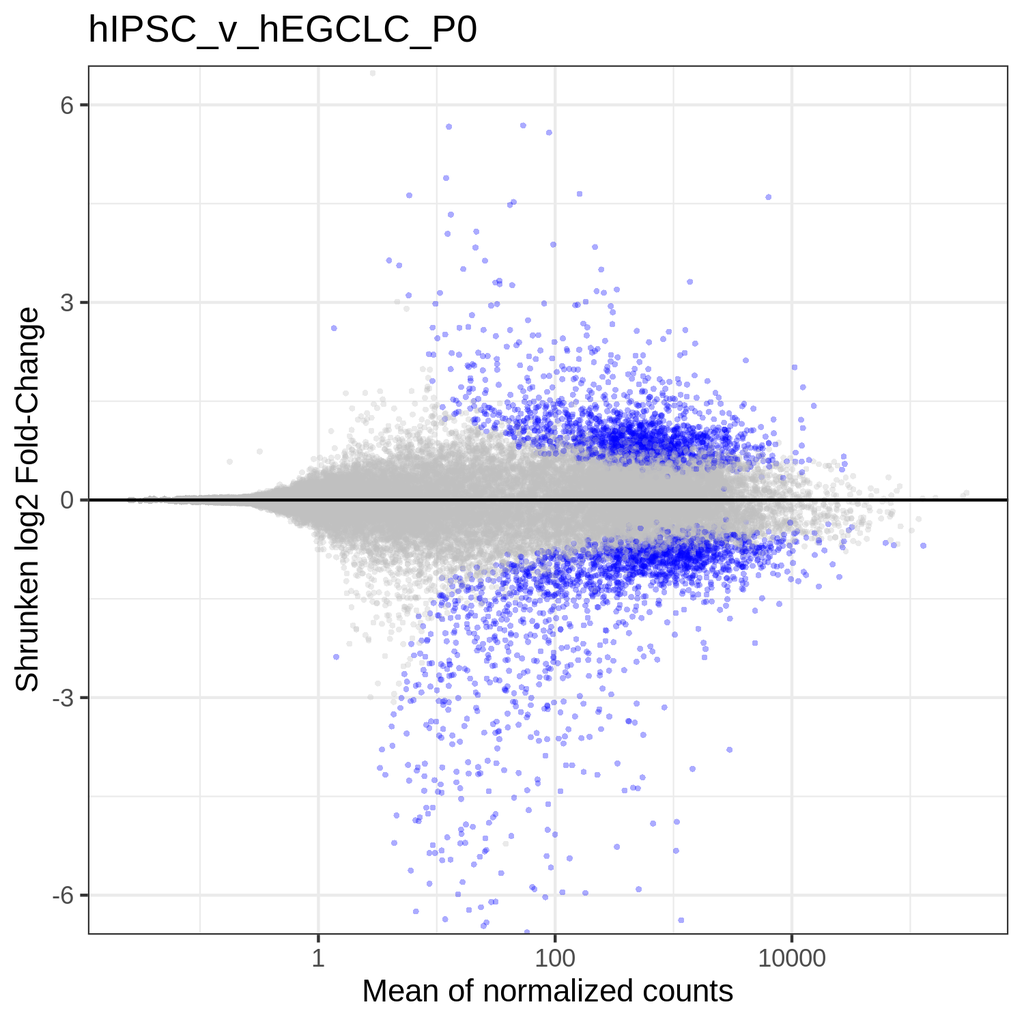

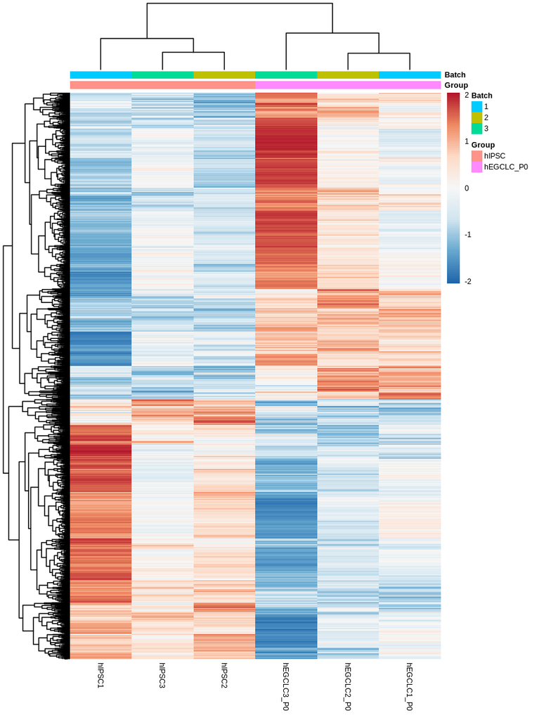

### hPGCLC_v_hEGCLC_P0

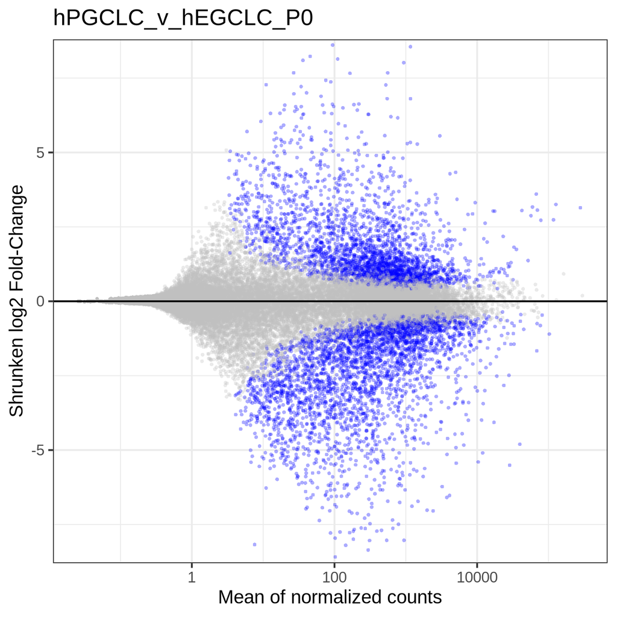

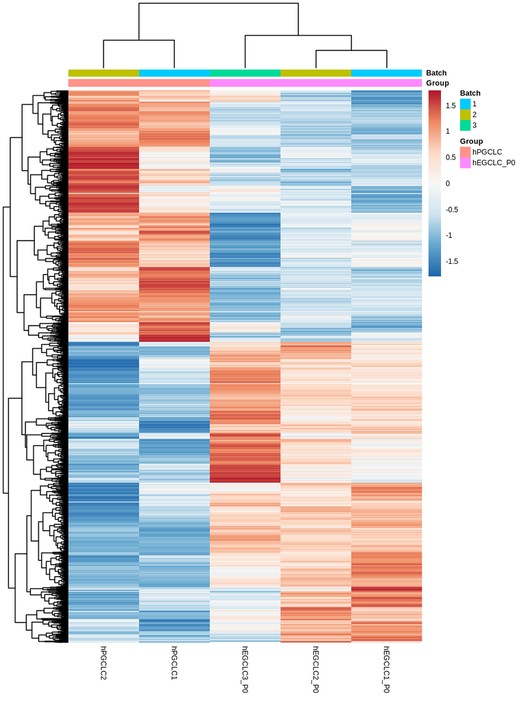

### hEGCLC_P0_v_hEGCLC_P3

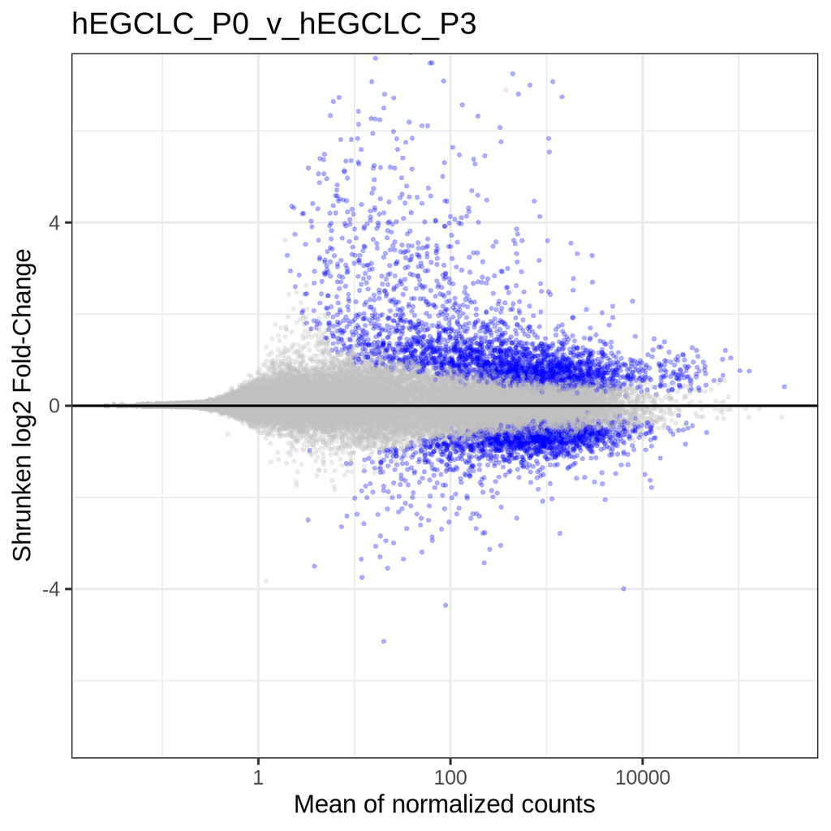

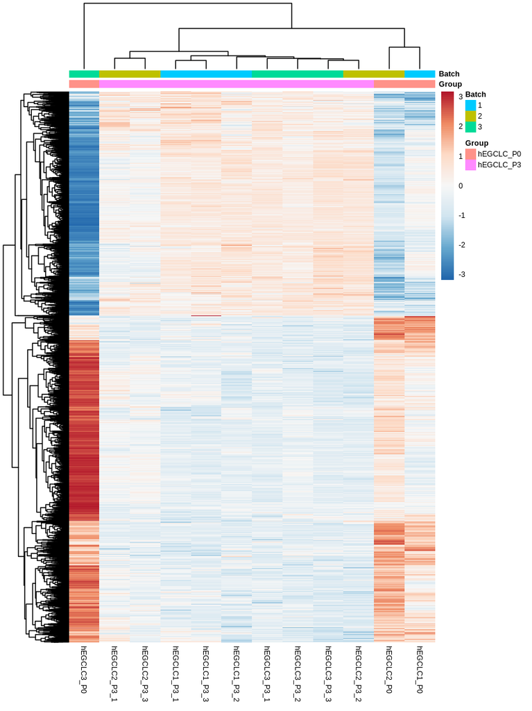

### hEGCLC_P0_v_hEGCLC_P5

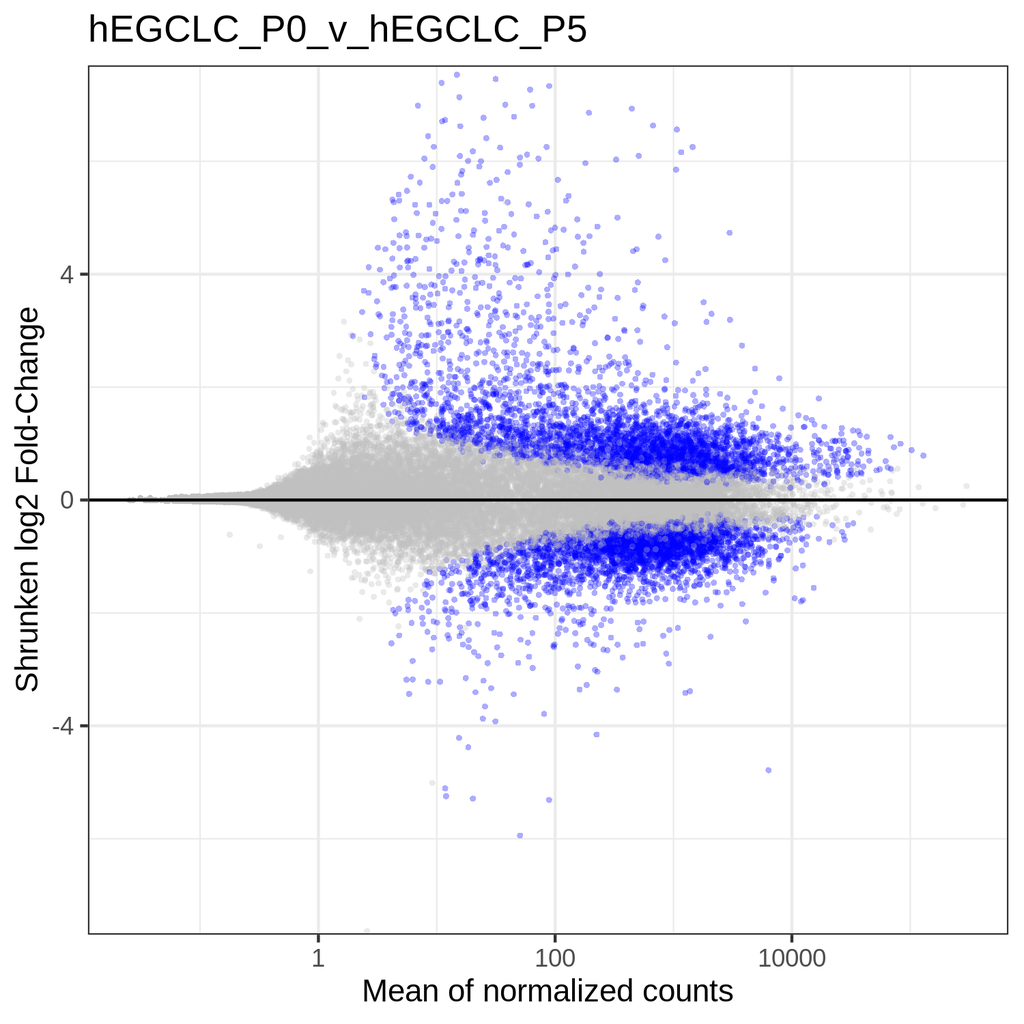

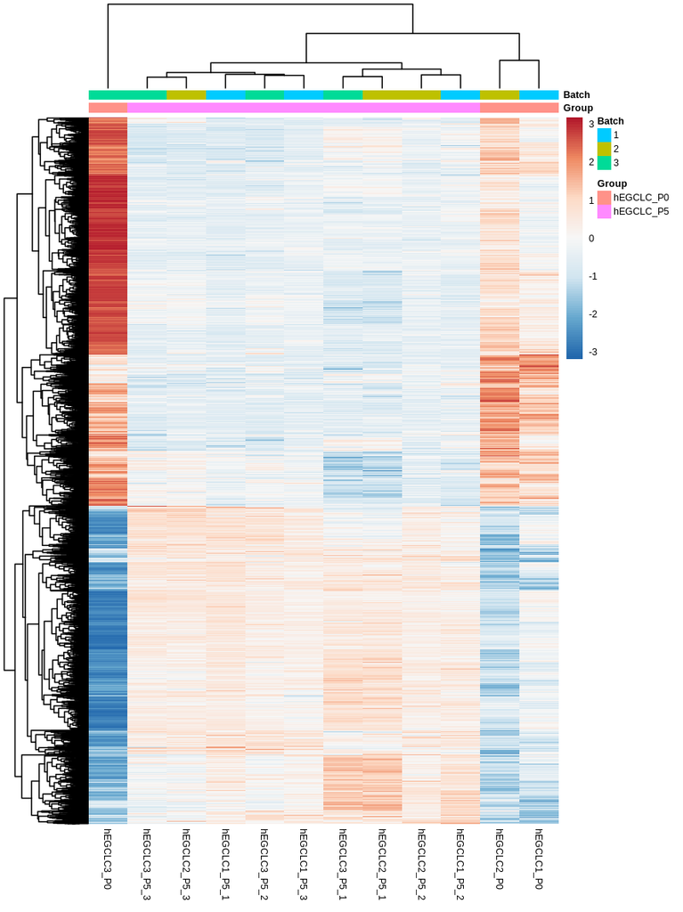

```r
rm(contrast)
```

## GO analysis

```r
if (snap > current_snapshot) {

  go_alpha = 0.05

  for (contrast in c("hEGCLC_P3_v_hIPSC", "hEGCLC_P5_v_hIPSC")) {

    goUP = clusterProfiler::enrichGO(
      gene=dplyr::filter(contrasts[[contrast]]$results, log2FoldChange>0) %>% dplyr::pull(gene_id),
      OrgDb=org.Hs.eg.db, keyType='ENSEMBL', ont="BP",
      pAdjustMethod="BH", pvalueCutoff=go_alpha, qvalueCutoff=go_alpha, readable=T)

    readr::write_tsv(
      dplyr::filter(goUP@result, p.adjust<go_alpha, qvalue<go_alpha),
      here(outputs$contrasts, glue("{contrast}_goUP.tsv")))

    if (nrow(dplyr::filter(goUP@result, p.adjust<go_alpha, qvalue<go_alpha))) {

      g = clusterProfiler::dotplot(goUP, showCategory=25) +
        ggplot2::theme(axis.text.y=element_text(size=8))
      ggsaver(
        glue("{contrast}_goUP_dotplot"), g, path=outputs$contrasts,
        height=25, width=15, units="cm")

      # g = enrichplot::treeplot(enrichplot::pairwise_termsim(goUP))
      # ggsaver(
      #   glue("{contrast}_goUP_treeplot"), g, path=outputs$contrasts,
      #   height=15, width=25, units="cm")

    }

    rm(goUP, g)

    goDOWN = clusterProfiler::enrichGO(
      gene=dplyr::filter(contrasts[[contrast]]$results, log2FoldChange<0) %>% dplyr::pull(gene_id),
      OrgDb=org.Hs.eg.db, keyType='ENSEMBL', ont="BP",
      pAdjustMethod="BH", pvalueCutoff=go_alpha, qvalueCutoff=go_alpha, readable=T)

    readr::write_tsv(
      dplyr::filter(goDOWN@result, p.adjust<go_alpha, qvalue<go_alpha),
      here(outputs$contrasts, glue("{contrast}_goDOWN.tsv")))

    if (nrow(dplyr::filter(goDOWN@result, p.adjust<go_alpha, qvalue<go_alpha))) {

      g = clusterProfiler::dotplot(goDOWN, showCategory=25) +
        ggplot2::theme(axis.text.y=element_text(size=8))
      ggsaver(
        glue("{contrast}_goDOWN_dotplot"), g, path=outputs$contrasts,
        height=25, width=15, units="cm")

      # g = enrichplot::treeplot(enrichplot::pairwise_termsim(goDOWN))
      # ggsaver(
      #   glue("{contrast}_goUP_treeplot"), g, path=outputs$contrasts,
      #   height=15, width=25, units="cm")

    }

    rm(goDOWN, g)

  }

  rm(go_alpha, contrast)

}
```

```r
for (contrast in c("hEGCLC_P3_v_hIPSC", "hEGCLC_P5_v_hIPSC")) {
  cat(glue("### {contrast}"))
  if (file.exists(here(outputs$contrasts, glue("{contrast}_goUP_dotplot.png")))) {
    cat("\nGO terms enriched within DE genes with positive l2FC\n")
    cat(glue('![]({here(outputs$contrasts, glue("{contrast}_goUP_dotplot.png"))})'))
  }
  if (file.exists(here(outputs$contrasts, glue("{contrast}_goDOWN_dotplot.png")))) {
    cat("\nGO terms enriched within DE genes with negative l2FC\n")
    cat(glue('![]({here(outputs$contrasts, glue("{contrast}_goDOWN_dotplot.png"))})'))
  }
  cat("\n\n")
}
```

### hEGCLC_P3_v_hIPSC

GO terms enriched within DE genes with positive l2FC

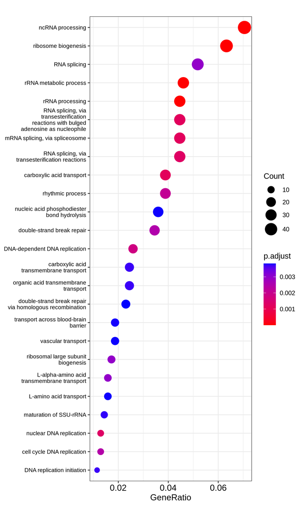

GO terms enriched within DE genes with negative l2FC

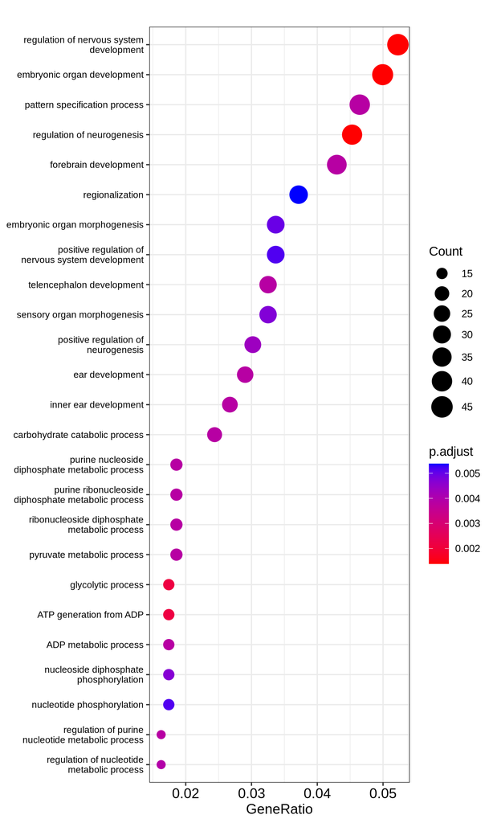

### hEGCLC_P5_v_hIPSC

GO terms enriched within DE genes with negative l2FC

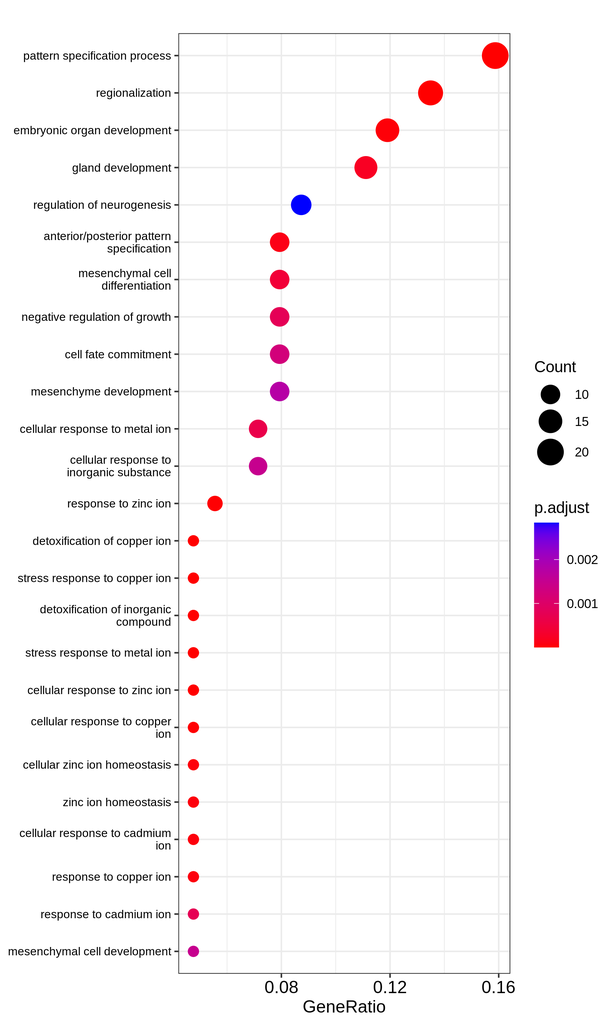

## Heatmaps

```r
if (snap > current_snapshot) {

  heatmaps = list(
    "pluripotency_pgc"=list(
      "heatmap_genes"=c("ENSG00000181449", "ENSG00000204531", "ENSG00000111704", "ENSG00000136826", "ENSG00000115112", "ENSG00000087510", "ENSG00000057657", "ENSG00000147596", "ENSG00000187556", "ENSG00000164736", "ENSG00000152670", "ENSG00000092345", "ENSG00000119888", "ENSG00000091409", "ENSG00000256453"),
      "heatmap_labels"=c("SOX2", "POU5F1", "NANOG", "KLF4", "TFPCP2L1", "TFAP2C", "PRDM1", "PRDM14", "NANOS3", "SOX17", "DDX4", "DAZL", "EPCAM", "ITGA6", "DND1"),
      "heatmap_samples"=meta_data$Sample),
    "dna_methylation"=list(
      "heatmap_genes"=c("ENSG00000130816", "ENSG00000119772", "ENSG00000088305", "ENSG00000142182", "ENSG00000276043", "ENSG00000138336", "ENSG00000168769", "ENSG00000187605"),
      "heatmap_labels"=c("DNMT1", "DNMT3A", "DNMT3B", "DNMT3L", "UHRF1", "TET1", "TET2", "TET3"),
      "heatmap_samples"=meta_data$Sample),
    "others"=list(
      "heatmap_genes"=c("ENSG00000165588", "ENSG00000163508", "ENSG00000240563", "ENSG00000137203", "ENSG00000127528", "ENSG00000141665", "ENSG00000077800"),
      "heatmap_labels"=c("OTX2", "EOMES", "L1TD1", "TFAP2A", "KLF2", "FBXO15", "FKBP6"),
      "heatmap_samples"=meta_data$Sample)
  )

  purrr::map(
      names(heatmaps),
      function(heatmap) {
        vsd =
          assay(DESeq2::vst(dds)) %>%
            data.frame %>%
            dplyr::slice(match(heatmaps[[heatmap]]$heatmap_genes, rownames(dds))) %>%
            dplyr::select(heatmaps[[heatmap]]$heatmap_samples)
        if (is.null(nrow(vsd))) return(NULL)
        vsd = vsd[apply(vsd, 1, function(x) length(unique(x)) != 1), ]
        if (is.null(nrow(vsd))) return(NULL)
        annot =
          meta_data %>%
            tibble::column_to_rownames("Sample") %>%
            dplyr::select(Group, Batch)
        png(
          here(outputs$figures, glue("{heatmap}_heatmap.png")),
          width=15, height=10, units="cm", res=150)
        pheatmap::pheatmap(
          vsd,
          annotation=annot,
          scale="row",
          labels_row=heatmaps[[heatmap]]$heatmap_labels,
          cluster_rows=TRUE,
          cluster_cols=TRUE,
          show_rownames=TRUE,
          show_colnames=TRUE,
          color=colorRampPalette(rev(brewer.pal(n=7, name="RdBu")))(100),
          fontsize=6,
          cellwidth=10,
          cellheight=10)
        dev.off()
      })

}
```

```r
for (heatmap in names(heatmaps)){
  cat(glue("### {heatmap}"))
  cat("\n\n")
  cat(glue('![]({here(outputs$figures, glue("{heatmap}_heatmap.png"))})'))
  cat("\n\n")
}
```

### pluripotency_pgc

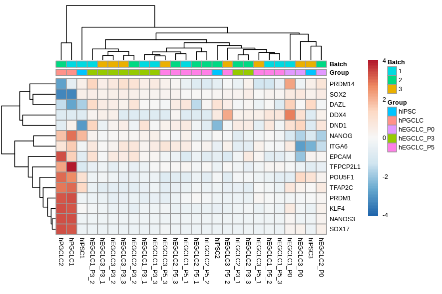

### dna_methylation

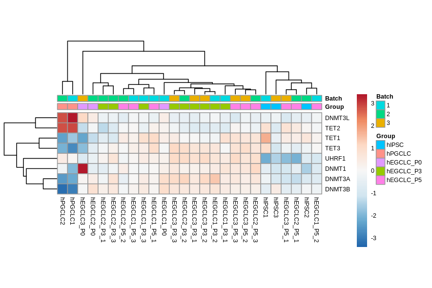

### others

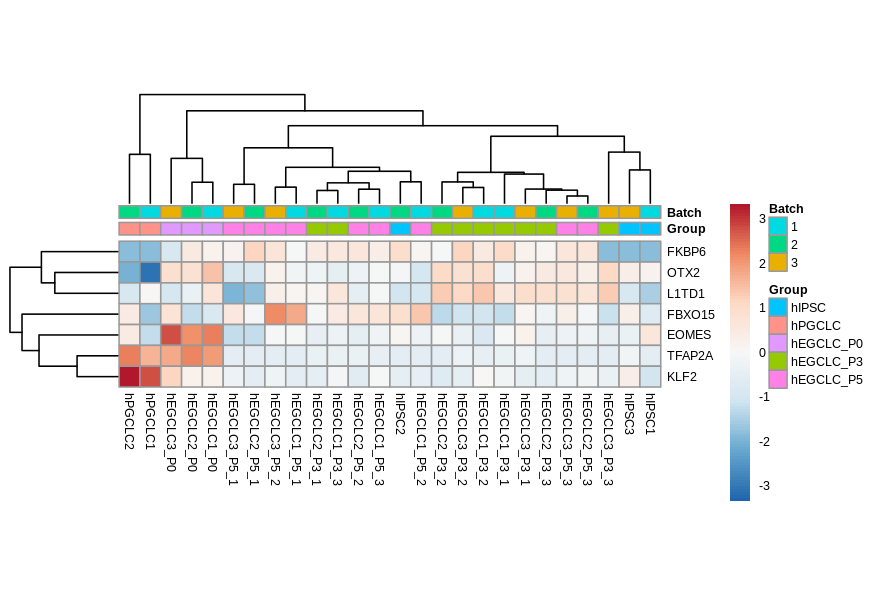

# References

Ignatiadis, Nikolaos, Bernd Klaus, Judith B Zaugg, and Wolfgang Huber. 2016. “Data-Driven Hypothesis Weighting Increases Detection Power in Genome-Scale Multiple Testing.” *Nature Methods* 13 (7): 577–80. https://doi.org/10.1038/nmeth.3885.

Love, M I, W Huber, and S Anders. 2014. “Moderated Estimation of Fold Change and Dispersion for RNA-Seq Data with DESeq2.” *Genome Biology* 15 (12): 550–50. https://doi.org/10.1186/s13059-014-0550-8.

Martin, Marcel. 2011. “Cutadapt Removes Adapter Sequences from High-Throughput Sequencing Reads.” *EMBnet.journal* 17 (1): 10–12. https://doi.org/10.14806/ej.17.1.200.

Patro, Rob, Geet Duggal, Michael I Love, Rafael A Irizarry, and Carl Kingsford. 2017. “Salmon Provides Fast and Bias-Aware Quantification of Transcript Expression.” *Nature Methods* 14 (4): 417–19.

Stephens, Matthew. 2017. “False Discovery Rates: A New Deal.” *Biostatistics* 18 (2): 275–94. https://doi.org/10.1093/biostatistics/kxw041.